# LongPron: Tracking Longitudinal L2 Pronunciation Research

Last Update: 2023-11-08

# Overview

**Statement of Purpose**  
This webpage is periodically updated with new longitudinal L2 pronunciation research that does not have a pronunciation-specific intervention. On this page, you can see the types of longitudinal studies that have been conducted up to this point, focusing on longitudinal design choices, such as study length and data points, and their intersection with participant sample and measurement characteristics. This page accompanies and builds upon

Nagle, C. L. (2021). Assessing the state of the art in longitudinal L2 pronunciation research: Trends and future directions. *Journal of Second Language Pronunciation*, *7*(2), 154-182. http://doi.org/10.1075/jslp.20059.nag

In that publication, I synthesized longitudinal pronunciation research that met three basic inclusion criteria: (1) tracked the same groups of participants over two or more data points, (2) did not include pronunciation-related training or a pronunciation-specific intervention, and (3) was published after 2006 in a peer-reviewed journal.

I am now expanding beyond the initial scope of that study, and I have reconfigured the data set from the format published and analyzed in Nagle (2021). In the updated data set, I treat each sample as an individual entry, which means that research reports that include multiple samples have multiple entries. By treating each sample as an individual entry in the data set, we can see how many unique longitudinal samples have been collected, including samples that were included in the same research report. Some researchers have analyzed the same group of participants in several reports, but it is not always clear if the sample is the exact same across reports, so I treat those samples as unique. Research reports may have multiple samples for any of the following reasons: (1) L1 background, (2) age range, (3) context of learning. The “Multiple Entry” variable allows the data to be subset to exclude multiple entries to avoid double counting studies for certain tabulations, such as study length, data points, and so on.

**Researchers**  
If you have published a longitudinal L2 pronunciation study that you think should be included in this webpage, please email me the citation so that I can review it and incorporate it if appropriate.

**Authors**  
If you believe that there has been an error in the coding for your article, please contact me.

**Users**  
If there is a particular cross-tabulation you’re interested in but don’t see it here, please contact me.

**My Contact Information**  
Charlie Nagle  
The University of Texas at Austin  
Email: cnagle[at]austin.utexas.edu

**APA 7 Citation**  
Nagle, C. (Year, Month Day). *LongPron: Tracking longitudinal L2 pronunciation research*. https://cnagle5.github.io/longpron/

# Current Data Set

```r
long.data <- read.csv(
  file = here("New Longitudinal Research Synthesis.csv")) %>%
  clean_names() %>%
  mutate(length_bin = fct_relevel(length_bin, "0 to 4", "4 to 8", "8 to 12", "12 to 24", "24+"),
         participant_age_bin = fct_relevel(participant_age_bin, "Child", "Adolescent", "Adult"))
```

```r
long.data %>%
  rmarkdown::paged_table()
```

| study_title | study_authors | study_first_author | study_year | study_venue | nagle_2021 | multiple_entry | experimental | length_total | length_months | length_bin | data_points_number | data_points_spacing | if_unequal_exact_spacing | participant_n | participant_age | participant_age_bin | context_fl | context_sa | context_sl | l1 | l2 | perception | production_specific | production_global | task_controlled | task_spontaneous | coding_linguistic_or_acoustic_properties | coding_expert_rating | coding_human_intuition | … |
| --- | --- | --- | --- | --- | --- | --- | --- | --- | --- | --- | --- | --- | --- | --- | --- | --- | --- | --- | --- | --- | --- | --- | --- | --- | --- | --- | --- | --- | --- | --- |
| Development of comprehensibility and its linguistic correlates: A longitudinal study of video-mediated telecollaboration | Akiyama Saito | Akiyama | 2016 | Modern Language Journal | Yes | No | No | 1 semester | 4.00 | 0 to 4 | 2 | na |  | 30 | 20.5 | Adult | Yes | No | No | English | Japanese | No | Yes | Yes | No | Yes | No | Yes | Yes | … |
| The longitudinal development of fine‐phonetic detail: Stop production in a domestic immersion program | Casillas | Casillas | 2020 | Language Learning | Yes | No | No | 8 weeks | 2.00 | 0 to 4 | 8 | Equal |  | 10 | 23.7 | Adult | No | Yes | No | English | Spanish | No | Yes | No | Yes | No | Yes | No | No | … |
| The development of L2 oral language skills in two L1 groups: A 7-year study | Derwing Munro | Derwing | 2013 | Language Learning | Yes | No | No | 7 years | 84.00 | 24+ | 3 | Unequal | 2 months, 2 years, 7 years | 11 | 42 | Adult | No | No | Yes | Mandarin | English | No | No | Yes | No | Yes | No | No | Yes | … |
| The development of L2 oral language skills in two L1 groups: A 7-year study | Derwing Munro | Derwing | 2013 | Language Learning | Yes | Yes | No | 7 years | 84.00 | 24+ | 3 | Unequal | 2 months, 2 years, 7 years | 11 | 45.8 | Adult | No | No | Yes | Slavic | English | No | No | Yes | No | Yes | No | No | Yes | … |
| The relationship between L1 fluency and L2 fluency development | Derwing Munro Thomson Rossiter | Derwing | 2009 | Studies in Second Language Acquisition | Yes | No | No | 2 years | 24.00 | 12 to 24 | 3 | Unequal | 0, 2, 10, 22 months | 16 | 34.33 | Adult | No | No | Yes | Mandarin | English | No | Yes | No | No | Yes | No | Yes | Yes | … |
| The relationship between L1 fluency and L2 fluency development | Derwing Munro Thomson Rossiter | Derwing | 2009 | Studies in Second Language Acquisition | Yes | Yes | No | 2 years | 24.00 | 12 to 24 | 3 | Unequal | 0, 2, 10, 22 months | 16 | 38.5 | Adult | No | No | Yes | Slavic | English | No | Yes | No | No | Yes | No | Yes | Yes | … |
| A longitudinal study of listening perception in adult learners of English: Implications for teachers | Derwing Thomson Foote Munro | Derwing | 2012 | Canadian Modern Language Review | Yes | No | No | 10 months | 10.00 | 8 to 12 | 5 | Equal |  | 20 | 33.6 | Adult | No | No | Yes | Mandarin | English | Yes | No | No | No | No | No | No | No | … |
| A longitudinal study of listening perception in adult learners of English: Implications for teachers | Derwing Thomson Foote Munro | Derwing | 2012 | Canadian Modern Language Review | Yes | Yes | No | 10 months | 10.00 | 8 to 12 | 5 | Equal |  | 20 | 39.5 | Adult | No | No | Yes | Slavic | English | Yes | No | No | No | No | No | No | No | … |
| The development of Chinese fluency during study abroad in China | Du | Du | 2013 | Modern Language Journal | Yes | No | No | 4 months | 4.00 | 0 to 4 | 4 | Equal |  | 29 | 20.5 | Adult | No | Yes | No | English | Mandarin | No | Yes | No | No | Yes | Yes | No | No | … |
| A longitudinal investigation of vowel acquisition | Gulinello | Gulinello | 2009 | Pronunciation in Second Language Learning and Teaching | Yes | No | No | 1 year | 12.00 | 8 to 12 | 3 |  |  | 5 | nr | Adult | No | No | Yes | Spanish | English | No | Yes | No | Yes | No | Yes | No | No | … |

[output cut: 55 more lines]

# Publication Trends

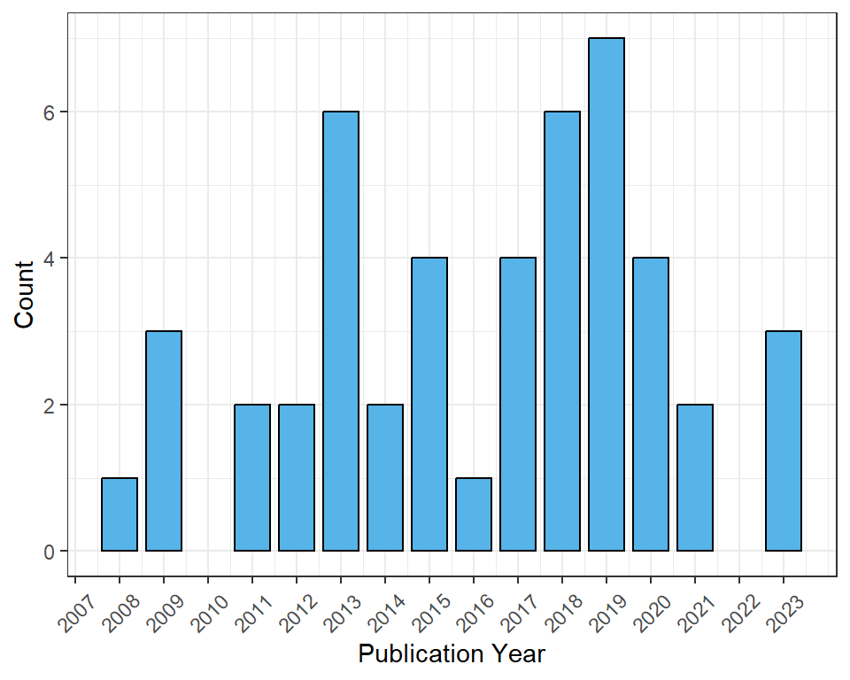

**Figure 1**. Longitudinal L2 Pronunciation Publications by Year

```r
long.data %>%
  filter(multiple_entry == "No") %>%
  ggplot(aes(x = study_year)) +
  geom_bar(stat = "count", color = "black", fill = "#56B4E9", width = 0.8) +
  theme_bw() +
  labs(x = "Publication Year", y = "Count") +
  scale_x_continuous(breaks = c(2006:2023)) +
  theme(axis.text.x = element_text(angle = 45, vjust = .5))
```

# Longitudinal Characteristics

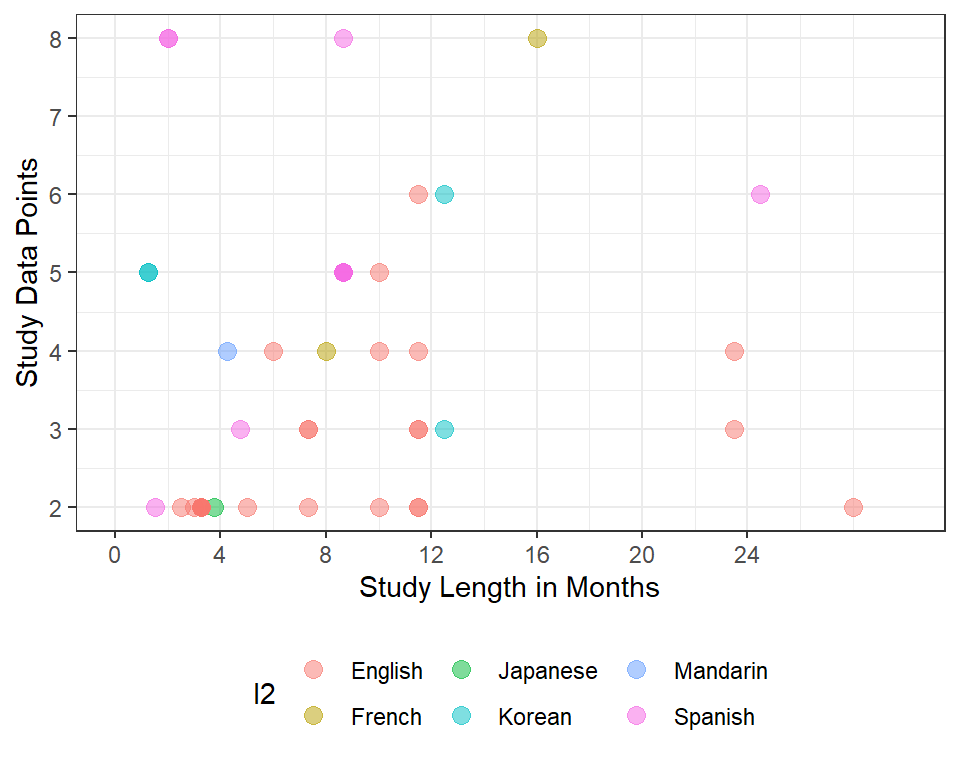

**Figure 2**. Study Length by Data Points

```r
long.data %>%
  filter(multiple_entry == "No") %>%
  ggplot(aes(x = length_months, y = data_points_number, color = l2)) +
  geom_point(position = position_dodge(width = 2), alpha = 0.5, size = 3) +
  theme_bw() +
  labs(x = "Study Length in Months", y = "Study Data Points") +
  theme(legend.position = "bottom") +
  scale_y_continuous(breaks = c(2:8)) +
  scale_x_continuous(breaks = c(0, 4, 8, 12, 16, 20, 24), limits=c(0, 30))
```

```r
long.data %>%
  filter(multiple_entry == "No") %>%
  tabyl(length_bin, data_points_number) %>%
  adorn_totals( where = c("row", "col") ) %>%
  adorn_percentages("row") %>%
  adorn_pct_formatting() %>%
  adorn_ns( position = "front" ) %>%
  adorn_title("combined") %>%
  kable(caption = "**Table 1**. Study Length by Study Data Points") %>%
  kable_styling(bootstrap_options = c("bordered", "hover"))
```

**Table 1**. Study Length by Study Data Points

| length_bin/data_points_number | 2 | 3 | 4 | 5 | 6 | 8 | Total |
| --- | --- | --- | --- | --- | --- | --- | --- |
| 0 to 4 | 10 (62.5%) | 1 (6.2%) | 1 (6.2%) | 2 (12.5%) | 0 (0.0%) | 2 (12.5%) | 16 (100.0%) |
| 4 to 8 | 2 (18.2%) | 2 (18.2%) | 2 (18.2%) | 4 (36.4%) | 0 (0.0%) | 1 (9.1%) | 11 (100.0%) |
| 8 to 12 | 3 (27.3%) | 3 (27.3%) | 2 (18.2%) | 1 (9.1%) | 2 (18.2%) | 0 (0.0%) | 11 (100.0%) |
| 12 to 24 | 0 (0.0%) | 1 (25.0%) | 1 (25.0%) | 0 (0.0%) | 1 (25.0%) | 1 (25.0%) | 4 (100.0%) |
| 24+ | 3 (60.0%) | 1 (20.0%) | 0 (0.0%) | 1 (20.0%) | 0 (0.0%) | 0 (0.0%) | 5 (100.0%) |
| Total | 18 (38.3%) | 8 (17.0%) | 6 (12.8%) | 8 (17.0%) | 3 (6.4%) | 4 (8.5%) | 47 (100.0%) |

# Longitudinal Characteristics by Sample Characteristics

## Age Group

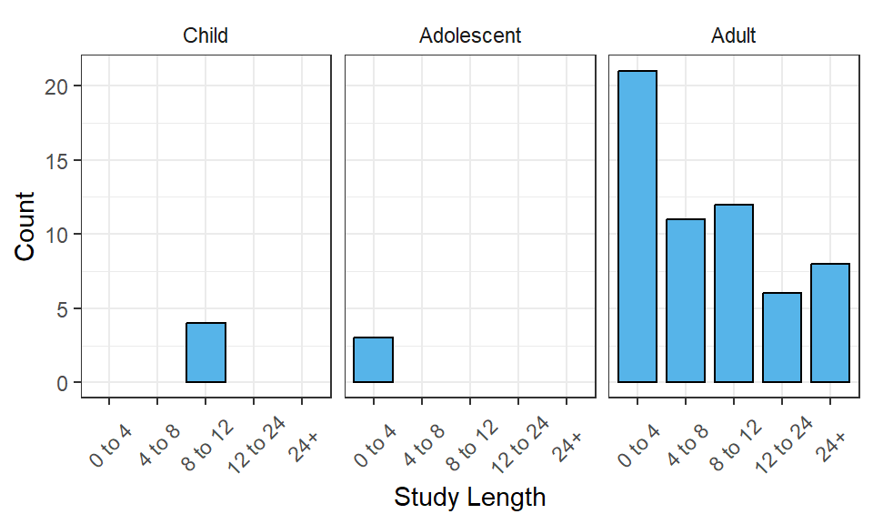

**Figure 3**. Number of Unique Samples: Study Length by Learner Age Group

```r
long.data %>%
  ggplot(aes(x = length_bin)) +
  geom_bar(stat = "count", color = "black", fill = "#56B4E9", width = 0.8) +
  theme_bw() +
  labs(x = "Study Length", y = "Count") +
  facet_wrap(~ participant_age_bin) +
  theme(strip.background = element_blank()) +
  theme(axis.text.x = element_text(angle = 45, vjust = .5))
```

## Context of Learning for Adult Learners

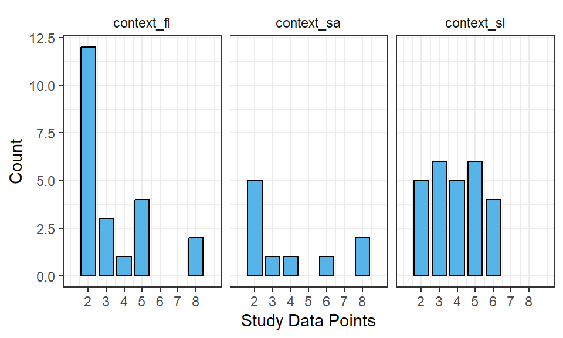

```r
long.data %>%
  filter(participant_age_bin == "Adult") %>%
  pivot_longer(cols = context_fl:context_sl,
               names_to = "context") %>%
  filter(value == "Yes") %>%
  ggplot(aes(x = data_points_number)) +
  geom_bar(stat = "count", color = "black", fill = "#56B4E9", width = 0.8) +
  theme_bw() +
  labs(x = "Study Data Points", y = "Count") +
  facet_grid(~ context) +
  theme(strip.background=element_blank()) +
  scale_x_continuous(limits = c(1,9), breaks = c(2:8))
```

# Longitudinal Characteristics by Measurement Characteristics

## Construct

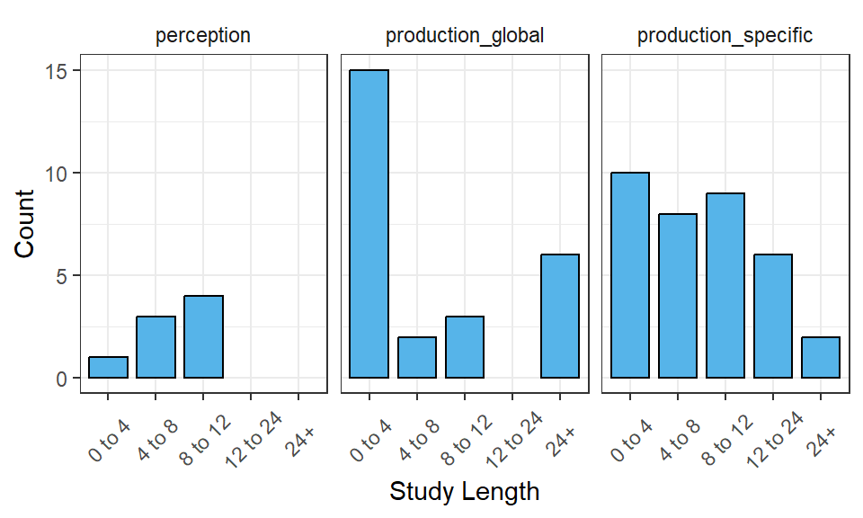

**Figure 5**. Number of Unique Samples: Study Length by Construct

```r
long.data %>%
  pivot_longer(cols = perception:production_global,
               names_to = "construct") %>%
  filter(value == "Yes") %>%
  ggplot(aes(length_bin)) +
  geom_bar(stat = "count", color = "black", fill = "#56B4E9", width = 0.8) +
  theme_bw() +
  labs(x = "Study Length", y = "Count") +
  facet_wrap(~ construct) +
  theme(strip.background = element_blank()) +
  theme(axis.text.x = element_text(angle = 45, vjust = .5))
```

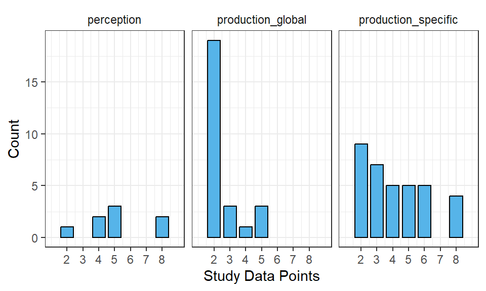

**Figure 6**. Number of Unique Samples: Study Data Points by Construct

```r
long.data %>%
  pivot_longer(cols = perception:production_global,
               names_to = "construct") %>%
  filter(value == "Yes") %>%
  ggplot(aes(data_points_number)) +
  geom_bar(stat = "count", color = "black", fill = "#56B4E9", width = 0.8) +
  theme_bw() +
  labs(x = "Study Data Points", y = "Count") +
  facet_wrap(~ construct) +
  theme(strip.background = element_blank()) +
  scale_x_continuous(limits = c(1, 9), breaks = c(2:8))
```

## Production Task

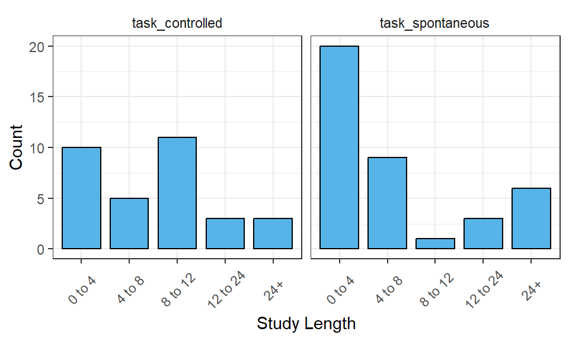

**Figure 7**. Number of Unique Samples: Study Length by Task Type

```r
long.data %>%
  pivot_longer(cols = task_controlled:task_spontaneous,
               names_to = "task") %>%
  filter(value == "Yes") %>%
  ggplot(aes(length_bin)) +
  geom_bar(stat = "count", color = "black", fill = "#56B4E9", width = 0.8) +
  theme_bw() +
  labs(x = "Study Length", y = "Count") +
  facet_wrap(~ task) +
  theme(strip.background = element_blank()) +
  theme(axis.text.x = element_text(angle = 45, vjust = .5))
```

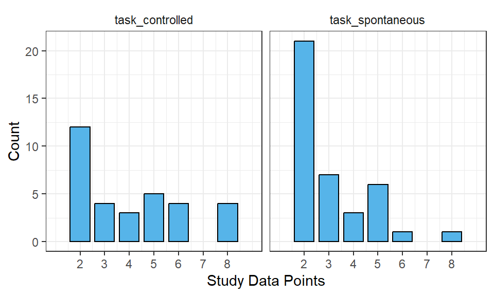

**Figure 8**. Number of Unique Samples: Study Data Points by Task Type

```r
long.data %>%
  pivot_longer(cols = task_controlled:task_spontaneous,
               names_to = "task") %>%
  filter(value == "Yes") %>%
  ggplot(aes(data_points_number)) +
  geom_bar(stat = "count", color = "black", fill = "#56B4E9", width = 0.8) +
  theme_bw() +
  labs(x = "Study Data Points", y = "Count") +
  facet_wrap(~ task) +
  theme(strip.background = element_blank()) +
  scale_x_continuous(limits = c(1, 9), breaks = c(2:8))
```

## Production Coding

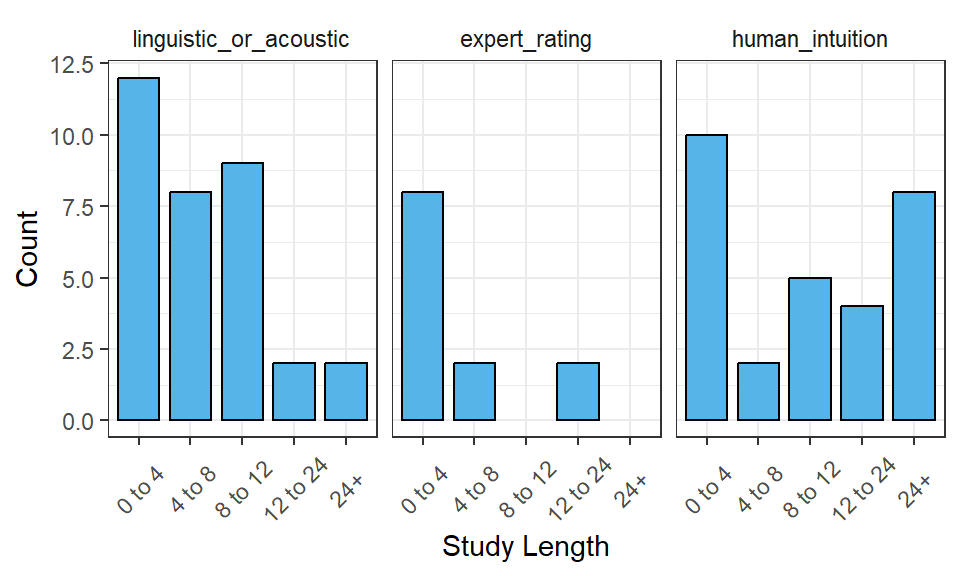

**Figure 9**. Number of Unique Samples: Study Length by Coding Approach

```r
long.data %>%
  mutate(linguistic_or_acoustic = coding_linguistic_or_acoustic_properties,
         expert_rating = coding_expert_rating,
         human_intuition = coding_human_intuition) %>%
  pivot_longer(cols = linguistic_or_acoustic:human_intuition,
               names_to = "coding_approach") %>%
  mutate(coding_approach = fct_relevel(coding_approach, c("linguistic_or_acoustic",
                                                          "expert_rating",
                                                          "human_intuition"))) %>%
  filter(value == "Yes") %>%
  ggplot(aes(length_bin)) +
  geom_bar(stat = "count", color = "black", fill = "#56B4E9", width = 0.8) +
  theme_bw() +
  labs(x = "Study Length", y = "Count") +
  facet_wrap(~ coding_approach) +
  theme(strip.background = element_blank()) +
  theme(axis.text.x = element_text(angle = 45, vjust = .5))
```

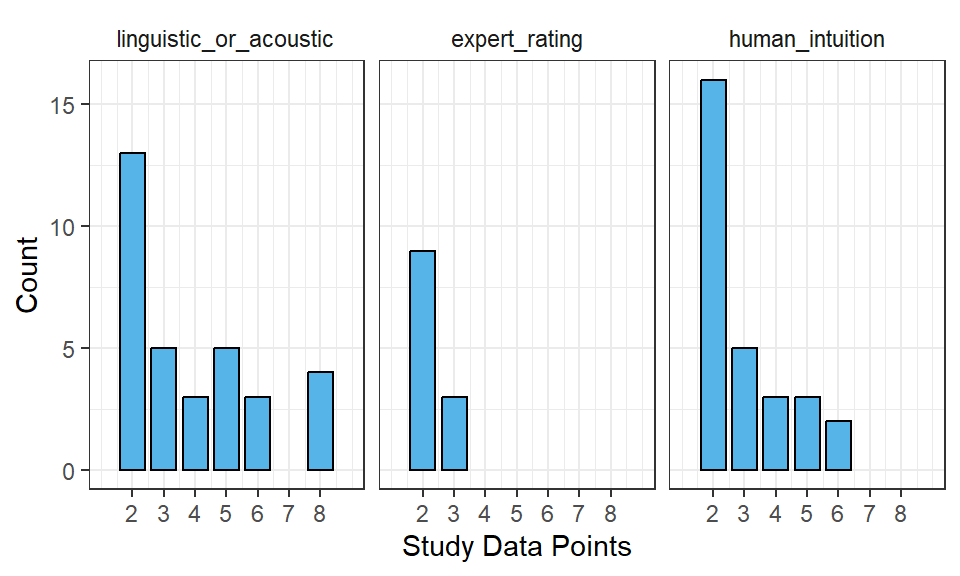

**Figure 10**. Number of Unique Samples: Study Data Points by Coding Approach

```r
long.data %>%
  mutate(linguistic_or_acoustic = coding_linguistic_or_acoustic_properties,
         expert_rating = coding_expert_rating,
         human_intuition = coding_human_intuition) %>%
  pivot_longer(cols = linguistic_or_acoustic:human_intuition,
               names_to = "coding_approach") %>%
  mutate(coding_approach = fct_relevel(coding_approach, c("linguistic_or_acoustic",
                                                          "expert_rating",
                                                          "human_intuition"))) %>%
  filter(value == "Yes") %>%
  ggplot(aes(data_points_number)) +
  geom_bar(stat = "count", color = "black", fill = "#56B4E9", width = 0.8) +
  theme_bw() +
  labs(x = "Study Data Points", y = "Count") +
  facet_wrap(~ coding_approach) +
  theme(strip.background = element_blank()) +
  scale_x_continuous(limits = c(1, 9), breaks = c(2:8))
```

# References

Akiyama, Y., & Saito, K. (2016). Development of comprehensibility and its linguistic correlates: A longitudinal study of video-mediated telecollaboration [Journal Article]. *The Modern Language Journal*, *100*(3), 585–609. https://doi.org/10.1111/modl.12338

Baker Smemoe, W., & Haslam, N. (2013). The effect of language learning aptitude, strategy use and learning context on L2 pronunciation learning [Journal Article]. *Applied Linguistics*, *34*(4), 435–456. https://doi.org/10.1093/applin/ams066

Buss, L., Cardoso, W., & Kennedy, S. (2015). Discourse intonation in L2 academic presentations: A pilot study [Book Section]. In J. Levis, R. Mohammed, M. Qian, & Z. Zhou (Eds.), *Proceedings of the 6th pronunciation in second language learning and teaching conference* (pp. 27–37). Iowa State University.

Casillas, J. V. (2020a). Phonetic category formation is perceptually driven during the early stages of adult L2 development [Journal Article]. *Language and Speech*, *63*(3), 550–581. https://doi.org/10.1177/0023830919866225

Casillas, J. V. (2020b). The longitudinal development of fine‐phonetic detail: Stop production in a domestic immersion program [Journal Article]. *Language Learning*, *70*(3), 768–806. https://doi.org/10.1111/lang.12392

Chang, C. B. (2012). Rapid and multifaceted effects of second-language learning on first-language speech production [Journal Article]. *Journal of Phonetics*, *40*(2), 249–268. https://doi.org/10.1016/j.wocn.2011.10.007

Chang, C. B. (2013). A novelty effect in phonetic drift of the native language [Journal Article]. *Journal of Phonetics*, *41*(6), 520–533. https://doi.org/10.1016/j.wocn.2013.09.006

Chang, C. B. (2019). Language change and linguistic inquiry in a world of multicompetence: Sustained phonetic drift and its implications for behavioral linguistic research [Journal Article]. *Journal of Phonetics*, *74*, 96–113. https://doi.org/10.1016/j.wocn.2019.03.001

Derwing, T. M., & Munro, M. J. (2013). The development of L2 oral language skills in two L1 groups: A 7-year study [Journal Article]. *Language Learning*, *63*(2), 163–185. https://doi.org/10.1111/lang.12000

Derwing, T. M., Munro, M. J., Thomson, R. I., & Rossiter, M. J. (2009). The relationship between L1 fluency and L2 fluency development [Journal Article]. *Studies in Second Language Acquisition*, *31*(4), 533–557.

Derwing, T. M., Thomson, R. I., Foote, J. A., & Munro, M. J. (2012). A longitudinal study of listening perception in adult learners of english: Implications for teachers [Journal Article]. *The Canadian Modern Language Review*, *68*(3), 247–266. https://doi.org/10.3138/cmlr.1215

Du, H. (2013). The development of chinese fluency during study abroad in china [Journal Article]. *The Modern Language Journal*, *97*(1), 131–143. https://doi.org/10.1111/j.1540-4781.2013.01434.x

George, A. (2014). Study abroad in central spain: The development of regional phonological features [Journal Article]. *Foreign Language Annals*, *47*(1), 97–114. https://doi.org/10.1111/flan.12065

Gulinello, F. (2010). A longitudinal investigation of vowel acquisition [Book Section]. In J. Levis & K. LeVelle (Eds.), *Proceedings of the 1st pronunciation in second language learning and teaching conference* (pp. 90–104). Iowa State University.

Holliday, J. J. (2015). A longitudinal study of the second language acquisition of a three-way stop contrast [Journal Article]. *Journal of Phonetics*, *50*, 1–14. https://doi.org/10.1016/j.wocn.2015.01.004

Huensch, A., & Tracy-Ventura, N. (2017). L2 utterance fluency development before, during, and after residence abroad: A multidimensional investigation [Journal Article]. *The Modern Language Journal*, *101*(2), 275–293. https://doi.org/10.1111/modl.12395

Kennedy, S., Foote, J. A., & Santos Buss, L. K. D. (2015). Second language speakers at university: Longitudinal development and rater behaviour [Journal Article]. *TESOL Quarterly*, *49*(1), 199–209. https://doi.org/10.1002/tesq.212

Kim, D., Clayards, M., & Goad, H. (2018). A longitudinal study of individual differences in the acquisition of new vowel contrasts [Journal Article]. *Journal of Phonetics*, *67*, 1–20. https://doi.org/10.1016/j.wocn.2017.11.003

Knouse, S. M. (2013). The acquisition of dialectal phonemes in a study abroad context: The case of the castilian theta [Journal Article]. *Foreign Language Annals*, *45*(4), 512–542. https://doi.org/10.1111/flan.12003

Muñoz, C., & Llanes, À. (2014). Study abroad and changes in degree of foreign accent in children and adults [Journal Article]. *The Modern Language Journal*, *98*(1), 432–449. https://doi.org/10.1111/j.1540-4781.2014.12059.x

Munro, M. J., & Derwing, T. M. (2008). Segmental acquisition in adult ESL learners: A longitudinal study of vowel production [Journal Article]. *Language Learning*, *58*(3), 479–502. https://doi.org/10.1111/j.1467-9922.2008.00448.x

Munro, M. J., Derwing, T. M., & Saito, K. (2013). English L2 vowel acquisition over seven years [Book Section]. In J. Levis & K. LeVelle (Eds.), *Proceedings of the 4th pronunciation in second language learning and teaching conference* (pp. 112–119). Iowa State University.

Munro, M. J., Derwing, T. M., & Thomson, R. I. (2015). Setting segmental priorities for english learners: Evidence from a longitudinal study [Journal Article]. *International Review of Applied Linguistics in Language Teaching*, *53*(1), 39–60. https://doi.org/10.1515/iral-2015-0002

Nagle, C. (2018). Motivation, comprehensibility, and accentedness in L2 spanish: Investigating motivation as a time-varying predictor of pronunciation development [Journal Article]. *The Modern Language Journal*, *102*(1), 199–217. https://doi.org/10.1111/modl.12461

Nagle, C. L. (2017). Individual developmental trajectories in the L2 acquisition of spanish spirantization [Journal Article]. *Journal of Second Language Pronunciation*, *3*(2), 218–241. https://doi.org/10.1075/jslp.3.2.03nag

Nagle, C. L. (2018). Examining the temporal structure of the perception-production link in second language acquisition: A longitudinal study [Journal Article]. *Language Learning*, *68*(1), 234–270. https://doi.org/10.1111/lang.12275

Nagle, C. L. (2019). A longitudinal study of voice onset time development in L2 spanish stops [Journal Article]. *Applied Linguistics*, *40*(1), 86–107. https://doi.org/10.1093/applin/amx011

Nagle, C. L. (2021). Revisiting perception–production relationships: Exploring a new approach to investigate perception as a time‐varying predictor [Journal Article]. *Language Learning*, *71*(1), 243–279. https://doi.org/10.1111/lang.12431

Oh, G. E., Guion-Anderson, S., Aoyama, K., Flege, J. E., Akahane-Yamada, R., & Yamada, T. (2011). A one-year longitudinal study of english and japanese vowel production by japanese adults and children in an english-speaking setting [Journal Article]. *J Phon*, *39*(2), 156–157. https://doi.org/10.1016/j.wocn.2011.01.002

Pesantez, A. C., & Dellwo, V. (2023). A longitudinal study of individual difference in foreign language pronunciation development: The case of vowel production in ecuadorian learners of english [Book Section]. In A. Henderson & A. Kirkova-Naskova (Eds.), *Proceedings of the 7th international conference on english pronunciation: Issues and practices*. https://doi.org/10.5281/zenodo.8225313

Richter, K. (2018). Factors affecting the pronunciation abilities of adult learners of english: A longitudinal group study [Book Section]. In *Exploring language aptitude: Views from psychology, the language sciences, and cognitive neuroscience* (pp. 339–361). https://doi.org/10.1007/978-3-319-91917-1_18

Saito, K. (2019). Individual differences in second language speech learning in classroom settings: Roles of awareness in the longitudinal development of japanese learners’ english /ɹ/ pronunciation [Journal Article]. *Second Language Research*, *35*(2), 149–172. https://doi.org/10.1177/0267658318768342

Saito, K., & Akiyama, Y. (2017). Video-based interaction, negotiation for comprehensibility, and second language speech learning: A longitudinal study [Journal Article]. *Language Learning*, *67*(1), 43–74. https://doi.org/10.1111/lang.12184

Saito, K., Dewaele, J. M., & Hanzawa, K. (2017). A longitudinal investigation of the relationship between motivation and late second language speech learning in classroom settings [Journal Article]. *Language and Speech*, *60*(4), 614–632. https://doi.org/10.1177/0023830916687793

Saito, K., Dewaele, J.-M., Abe, M., & In’nami, Y. (2018). Motivation, emotion, learning experience, and second language comprehensibility development in classroom settings: A cross-sectional and longitudinal study [Journal Article]. *Language Learning*, *68*(3), 709–743. https://doi.org/10.1111/lang.12297

Saito, K., & Hanzawa, K. (2018). The role of input in second language oral ability development in foreign language classrooms: A longitudinal study [Journal Article]. *Language Teaching Research*, *22*(4), 398–417. https://doi.org/10.1177/1362168816679030

Saito, K., Sun, H., & Tierney, A. (2020). Domain-general auditory processing determines success in second language pronunciation learning in adulthood: A longitudinal study [Journal Article]. *Applied Psycholinguistics*, *41*(5), 1083–1112. https://doi.org/10.1017/s0142716420000491

Saito, K., Suzuki, S., Oyama, T., & Akiyama, Y. (2019). How does longitudinal interaction promote second language speech learning? Roles of learner experience and proficiency levels [Journal Article]. *Second Language Research*, *37*(4), 547–571. https://doi.org/10.1177/0267658319884981

Saito, K., Suzukida, Y., & Sun, H. (2019). Aptitude, experience, and second language pronunciation proficiency development in classroom settings [Journal Article]. *Studies in Second Language Acquisition*, *41*(1), 201–225. https://doi.org/10.1017/s0272263117000432

Sturm, J. L. (2019). Current approaches to pronunciation instruction: A longitudinal case study in french [Journal Article]. *Foreign Language Annals*, *52*(1), 32–44. https://doi.org/10.1111/flan.12376

Sun, H., Saito, K., & Dewaele, J. (2023). Cognitive and sociopsychological individual differences, experience, and naturalistic second language speech learning: A longitudinal study [Journal Article]. *Language Learning*. https://doi.org/10.1111/lang.12561

Sun, H., Saito, K., & Tierney, A. (2021). A longitudinal investigation of explicit and implicit auditory processing in L2 segmental and suprasegmental acquisition [Journal Article]. *Studies in Second Language Acquisition*, *43*(3), 551–573. https://doi.org/10.1017/s0272263120000649

Thomson, R. I., Derwing, T. M., & Munro, M. J. (2023). How long can naturalistic L2 pronunciation learning continue in adults? A 10-year study [Journal Article]. *Language Awareness*, 1–23. https://doi.org/10.1080/09658416.2023.2227559

Trofimovich, P., Lightbown, P. M., Halter, R. H., & Song, H. (2009). Comprehension-based practice [Journal Article]. *Studies in Second Language Acquisition*, *31*(04), 609. https://doi.org/10.1017/s0272263109990040

Zielinski, B., & Pryor, E. (2020). Comprehensibility and everyday english use [Journal Article]. *Journal of Second Language Pronunciation*, *6*(3), 352–379. https://doi.org/10.1075/jslp.20011.zie